# Paleobotany and divergence time estimation using RevBayes

Ixchel Gonzalez-Ramirez

2022-06-12

## Introduction

A **bayesian total evidence dating** (TED) analysis simultaneously infer **the topology** and **the divergence time** of a set of terminals. This approach has several advantages. First, it doesn’t require us to place the fossils in a specific clade -as it is required for node dating-, instead, the fossil specimens are placed in the phylogeny based on their own **morphological** and **temporal** information. As a result, we obtain posterior probabilities on the fossil placements, as opposed of having to assume their phylogenetic position. Second, with this approach, we can include **more than one fossil** putatively belonging to a group, whereas in node dating we usually pick only the oldest fossil to calibrate a node of interest. By including all the fossils available for a group we may have a more complete picture of it.

But as interesting and promising as Bayesian TED analyses are, they are complex. As we analyze more empirical data under this model, we are starting to better understand the interaction of the different parts of the model. And it has become clear that it is important that we understand the implications of our modeling decisions.This tutorial was written by an empiricist with interest in TED methods. The objective of it is to serve as an **introduction to the Bayesian Total Evidence Dating Model**, using the software RevBayes. I will focus on discussing the **different components** of the model, highlighting the way we **express our prior believes** about our study system, and how these components and priors translate into RevBayes language scripts. An equally important objective for me is to facilitate an introduction to the *linguo* of Bayesian TED analyses and the structure of RevBayes. Throughout the tutorial, I will point out to several references and other tutorials where you will be able to dig into some of the topics we will only superficially cover. The code of this tutorial can be easily adapted to run a total-evidence analysis on your own data. For a more advanced tutorial on Bayesian TED analyses -including code for comparing different models and assessing the adequacy of the model- visit [this page](https://revbayes.github.io/tutorials/ted_workflow/). Finally, once you have completed this introductory workshop, I invite you to check the more extensive lecture recordings of our Time Divergence Estimation [one month long workshop](https://mikeryanmay.github.io/ted.workshop.github.io/).

#### A glimpse to the Bayesian Total Evidence Dating model

**The type of data**.

Before diving into the details of the model it is worth to mention the type of data you need to consider using the Bayesian TED model. When the study group includes extant and extinct terminals, the dataset typically includes **both molecular and a morphological traits**. But a TED analysis can also be performed using only morphological traits, this is particularly plausible in a case where all the terminals are fossils. There is nothing restrictive about the number of fossils used, but some recommendations are to have fossils widespread in time and among lineages.

**The Bayesian TED model**

A Bayesian Total Evidence Dating model can be understood as having several components, that are themselves models of specific processes (Fig.1). These components describe specific processes. All these components fit together in a general TED where they have the potential to inform each other through their interactions. As we can see in figure one, we have **models of character evolution** that describe the way in which characters (morphological or molecular) change across lineages. We have **clock models** that describe the rate at which changes (morphological or molecular) occur along lineages. And we also have a **timetree model** that describes how lineages change (appear and go missing) through time. So let’s walk through an example and review each of the five components of a Bayesian TED analysis!

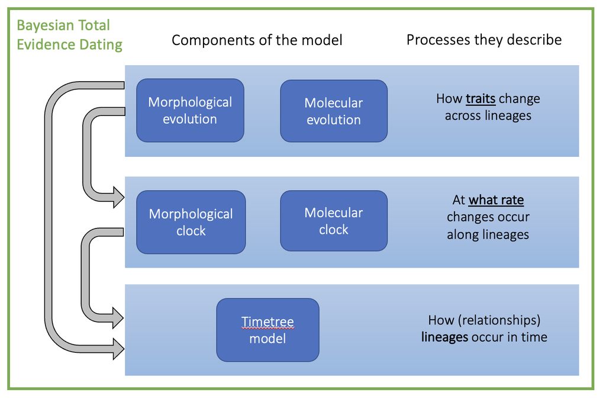

**Fig. 1.** Bayesian Total Evidence Dating Model. This model has 5 main components that are themselves modeling specific processes.

## The tutorial: Working through an example of the tomato family

### The files

In this tutorial we will work through an example of a Total Evidence Dating analysis using a very reduced dataset of extant and extinct species in the tomato family: Solanaceae. You can download all the data files and scripts for this tutorial in this link. In this tutorial we will be working with a set of 12 terminals, of which two are fossils. The molecular data are the alignments of three molecular markers: *ITS*, *TrnLF*, and *waxy*. The morphological matrix contains 16 traits.

### The directory organization

The files provided with this tutorial have a specific structure that facilitates clarity and organization. To avoid any problems, **don’t modify the provided structure**. The main folder is called **tutorial_evolution_2022**. All the scripts are written to be run from this main directory. You can run the complete analysis by opening your terminal in the folder **tutorial_evolution_2022**, and running the following command:

```r
rb scripts/TED_tutorial_evolution.Rev
```

But the objective of the tutorial is to explain some details of the code and how it reflects our modelling decisions and priors. So it is worth to take your time and run the analysis step by step.

The main directory contains three sub-directories: “data”, “scripts”, and “output”. The folder “**data**” contains the molecular alignments, the morphological data and the list of terminals with age information for the fossils. Feel free to explore the structure of each of these files by opening them in your text editor. The folder “**scripts**” contains all our code, and the folder “**output**” is where all our results files will be stored.

## The main script

As we mentioned before, a Bayesian TED analysis is modular: there are natural components -models by themselves- that come together into a larger and complex model. The organization of the scripts reflects this modularity. There is a main script, “**TED_tutorial_evolution.Rev**”, that puts together the different components by calling them with the function `source()`:

```r
# example, don't run this code
# I am running another script called "my_other_script.Rev"
source("my_other_script.Rev")
```

So let’s get started in the main script. In your text editor open the script **TED_tutorial_evolution.Rev**. You can follo along by copying and pasting the pieces of code in your terminal. Make sure you run the code from the folder **tutorial_evolution_2022**.

### Reading in and preparing the data

We will start by reading all the data: the sequence data, the morphological data and the taxon data. We will also obtain some useful information from it, like the number of alignments, the number of taxa, the number of branches in the tree, and the number of fossils in the dataset.

```r
# read the sequence data
# we specify the directory where all the alignments are stored
moledata = readDiscreteCharacterData("data/alignments/", alwaysReturnAsVector = TRUE)
naln     = moledata.size() # the number of alignments

# read the morphological data
morphdata = readDiscreteCharacterData("data/morphology.nexus")

# read the taxon data
taxa    = readTaxonData("data/taxa.tsv", delimiter=TAB)
ntax    = taxa.size()   # number of taxa
nbranch = 2 * ntax - 2  # number of branches in rooted phylogeny

# count the number of fossils using a for loop
num_fossils = 0

for(i in 1:taxa.size()) {
  if (taxa[i].getMinAge() != 0) {
    num_fossils = num_fossils + 1
  }
}
```

When we use more than one molecular marker, as in this example, it is often the case that some terminals are not represented in all the alignments, but RevBayes requires that all the alignments have the same taxa. The next *for loop* makes sure that all the terminals are in all the alignments.

```r
# the alignments do not have the total number of taxa,
# we need to manually add missing taxa to the sequence data:
for(i in 1:naln) {
  x = moledata[i]
  x.addMissingTaxa(taxa)
  moledata[i] = x
}
```

Next, we will prepare the morphological data. As opposed to molecular data that **only and always** has five possible character states: (A, C, G, T, -), morphological characters may have **different number of states**. Later in the tutorial, we will use a MK model for morphological evolution, that requires that our morphological data is partitioned by number of states. We will do this with a for loop, that iterates over the possible number of states, and retains only the characters that have a given number of states.

```r
# First, we add missing taxa to the morphological data
morphdata.addMissingTaxa(taxa)

# partition morphological data by number of states
  # the maximum number of states in my dataset
n_max_states = 10  # consider changing this for your own data, if necessary

  # start a counter
idx = 0

  # for each number of character states
for (i in 2:n_max_states) {

    # make a tempory character alignment
    morph_tmp <- morphdata

    # retain characters with i states
    morph_tmp.setNumStatesPartition(i)

    # if there are more than zero characters with this many states...
    # store the data partition
    if ( morph_tmp.nchar() > 0 ) {
        morph_partitions[++idx] = morph_tmp
        nc[idx] = i
    }
}


# compute the number of morphological partitions
num_morph_parts = morph_partitions.size()
```

Now our data is ready!

### Some RevBayes specifics

An important part of writing code in RevBayes is specifying the **moves** that the Markov Chain Monte Carlo (MCMC) will use to **make the proposals** on the value of the parameters that we are estimating. We usually specify at least one move per parameter, and sometimes we can use moves that operate in more than one parameter at the time (e.g. increasing the value of one parameter and decreasing the value of another). We usually specify the moves right after we specify the prior distribution of that parameter. We will keep track of all the moves we will use in our analysis by storing them in a single container: **a vector of moves**:

```r
# create empty vector of moves
# we will fill it as we specify moves
moves = VectorMoves()
```

As the MCMC explores the parameter space, it will keep track of the values of the parameters that we are estimating. Similarly to the container for the moves, we need a container for the sampled values of the parameters:

```r
# monitors vector
monitors = VectorMonitors()
```

The next piece of code will store in memory the number H, which happens to have some cool mathematical properties, like $\pi$ does.

```r
# convenient constants
H = ln(10) / (qnorm(0.975) - qnorm(0.025))
```

We are now ready to start specifying our model! If you want to learn more about moves, you can follow the tutorial [Introduction to MCMC using RevBayes](https://revbayes.github.io/tutorials/mcmc/binomial.html).